# Key Bacteria Selection with LASSO

lyjq

9/16/2021

# 1 Data preprocess

1. Sample metadata table
2. Relative abundance matrix of species level

# 2 KPC normal/pre-malignant vs. WT all

Selection of the key bacteria which discriminate KPC mice from wild type before the tumor is detectable.

## 2.1 Model Design

- Input matrix `mt1`:
  - select stage of wildtype, Normal and pre_malignant
  - select species presented (>0.1%) in more than 50% samples
- Response vector `y1`:
  - KPC mouse - 1
  - wildtype - 0

## 2.2 LASSO algorithm

Basically a regression algorithm minimizes the cost function of the residual sum of squares (RSS):

$$Cost = (y - X\beta)^\mathit{T}(y-X\beta)$$

The LASSO regression adds a penalty term L1 norm to the cost function:

$$Cost = (y-X\beta)^\mathit{T}(y-X\beta)+\lambda\lvert \beta \rvert$$
R package `glmnet` solves the best coefficients to minimize the cost terms.

`cv.glmnet` does cross validation to select the best model (lambda).

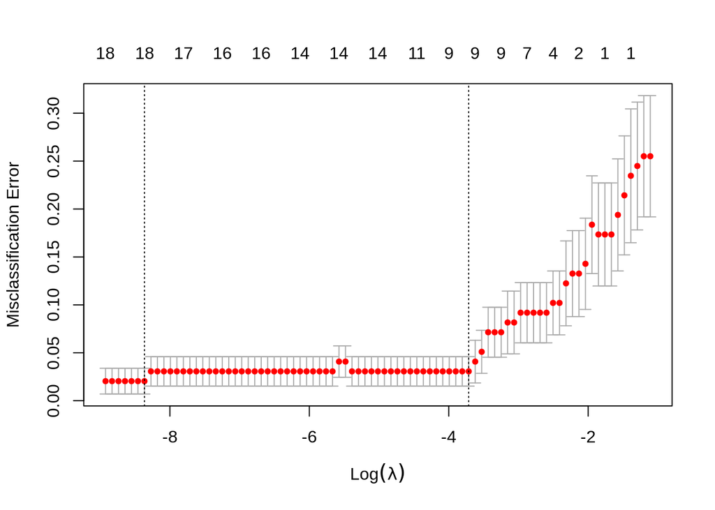

```
## [1] 0.02439442
```

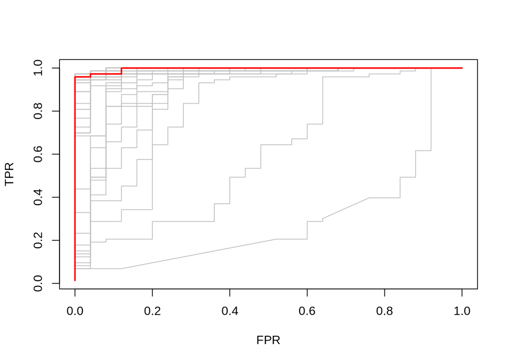

## 2.3 Selection of the key bacteria

Run 100 times LASSO, choose the species appeared in more than 80% runs.

```
##  [1] "(Intercept)"                  "Bifidobacterium_pseudolongum"
##  [3] "Bacteroides_caecimuris"       "Muribaculum_intestinale"
##  [5] "Prevotella_sp_MGM1"           "Parabacteroides_distasonis"
##  [7] "Lactobacillus_murinus"        "Lactobacillus_taiwanensis"
##  [9] "Faecalibaculum_rodentium"     "Turicimonas_muris"
```